# Final Project Submission Overview

Spring 2022

## Spring 2022 | Final Project Preparation + Upload Instructions

### Part I - Final Project Overview

#### Final Project Schedule:

Following **Class 13**, the first two weeks of May 2022 will be devoted to final project development.

- The final project due date: **Final Project Due 11:59PM 05/17/22**

#### Recorded Guide:

- Review the following video guide for image sequencing in QGIS for Google Slides:

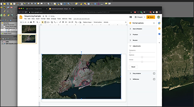

- Review the [Final Project Assignment](https://gis-nspe-tns.github.io/GIS_NINT5380_spring_2022/assignments/c13_assignment_spring_22_NINT5380.html) for strategies for final project design:
  - **Wayfinding - progress bars, numbering**
  - **Font Hierarchy**
  - **Page Space - Grid Formats**
  - **Variable Map Scales**
  - **Projection Systems**
  - **Slide progression and spatial bookmarks**
  - **Quantification + Summarization: Charts & Maps**

### Part II - Final Project Presentation + Methods Publication

#### Final Deliverable:

- The final deliverable consists of two components:
  - Presentation formatted in [Google Slides as a published presentation](https://support.google.com/docs/answer/183965?co=GENIE.Platform%3DDesktop&hl=en)
  - PDF Methods Paper formatted on [Google Drive as a published document](https://support.google.com/docs/answer/183965?co=GENIE.Platform%3DDesktop&hl=en)
- The final project submission is simply a `.txt` file with the following three items:
  - Project Abstract (approx. 150 - 200 words)
  - Published link to Methods
  - Published link to Project Presentation Slides
- Copy the following accessible and editable Google Document. Utilize it as the template for your `.txt` deliverable. This is the only document that needs to be uploaded to Canvas for the final project submission.
  - [Methods Link + Presentation Link + Abstract `.txt`](https://docs.google.com/document/d/1C4yxoQRvHP_wRNgY4b986qop4tRe5rv_voj-4lFNaVM/edit?usp=sharing)

#### Final Project Steps (extended) - also covered in [Final Project Step Slides in Lecture 13](https://gis-nspe-tns.github.io/GIS_NINT5380_spring_2022/lectures/lecture.13/index.html):

- **Step #1**:
  - Project Proposal (completed)
- **Step #2**:
  - Develop Methodology
- **Step #3**:
  - Conduct GIS analysis
- **Step #4**:
  - Complete analysis | Derive quantitative results | Summarization | Conclusive findings
- **Step #5A**:
  - Make back up of all data and analysis for future reference
  - Presentation Design | Methods Paper | Publish Documents | Canvas Upload
- **Step #5B - Slides**:
  - Finish Slides- either finalize and import to [Google Slides](https://www.google.com/slides/about/); or create slides from start to finish within [Google Slides](https://www.google.com/slides/about/)
- **Step #5C Methods**:
  - Complete methods paper at [Google Drive](https://www.google.com/drive/). Include the following subsections in the methods paper:
    - Abstract
    - Introduction
    - Methodology & Analysis
    - Results
    - Conclusion
    - Works Cited | Bibliography | Data Sources
- **Step #6 Publishing Links**:
  - Project Links Develop. Utilizing [Google Drive](https://www.google.com/drive/), create two (2) *share and publish links* - one for the methods paper, and one for the presentation:
    - **First**, ensure that `File > Share` is set to `Anyone with the link can view`:

[figure not shown]

    Step 1 Publishing Links - Open File to `view` status

    - **Second**, ensure that `File > Publish to the web` is set to `Publish` using the `link` option. The `Publish` link is the submission link, not the first `File > Share` link.

[figure not shown]

    Step 2 Publishing Links - Fully Publish the Link and Secure Correct Share Address

- **Step #7 Create and Upload to Canvas `your_name_final_GIS_project.txt`**:
  - Download the following `.txt` document as `.txt` and fill in the empty sections for your project details. Upload the completed `.txt` as `.txt` (not `.pdf` or `.doc`) to the assignment location at CANVAS:
    - [Project Paper Link + Presentation Link + Abstract `.txt`](https://docs.google.com/document/d/1C4yxoQRvHP_wRNgY4b986qop4tRe5rv_voj-4lFNaVM/edit?usp=sharing)
  - Ensure that both `Publish to the web` links (one for methods paper, one for slide presentation) as well as `copy >paste` of the abstract text from the methods paper is included in the [Project Paper Link + Presentation Link + Abstract `.txt`](https://docs.google.com/document/d/1C4yxoQRvHP_wRNgY4b986qop4tRe5rv_voj-4lFNaVM/edit?usp=sharing) submission.
  - Submit completed (copied and filled with your own project details) [Project Paper Link + Presentation Link + Abstract `.txt`](https://docs.google.com/document/d/1C4yxoQRvHP_wRNgY4b986qop4tRe5rv_voj-4lFNaVM/edit?usp=sharing) to the assignment section at Canvas for the Final Project.